# HMMs for Eye-Tracking - Works for All

Extract data

```r
setwd("~/Documents/Winter Project/eye-tracking")
```

```
The working directory was changed to /Users/Jeremy/Documents/Winter Project/eye-tracking inside a notebook chunk. The working directory will be reset when the chunk is finished running. Use the knitr root.dir option in the setup chunk to change the the working directory for notebook chunks.
```

```r
eyeseq <- read.csv("eyeseq.csv")
```

Create a function that allows for input for subject number and test number - do later

```r
library(ggplot2)
library(tidyr)
library(dplyr)
library(readr)
## Input the person and test here
mut_eye_x <- eyeseq %>%
  filter(people == 8) %>%
  filter(test == "M3")
```

```r
#Create dummies
plot <- matrix(NA,nrow(mut_eye_x),max(mut_eye_x$Plot))
for (i in 1:20) {
  nam <- paste("plot", i, sep = "")
  assign(nam, ifelse(mut_eye_x$Plot == i, 1, 0))
}
mut_eye_x <- cbind(mut_eye_x, plot1, plot2, plot3, plot4, plot5, plot6, plot7, plot8, plot9, plot10, plot11, plot12, plot13, plot14, plot15, plot16, plot17, plot18, plot19, plot20)
#Time in each
tms <- c(mut_eye_x$mxtm[1],diff(mut_eye_x$mxtm))
mut_eye_x <- mut_eye_x %>%
  mutate(count = tms)
#Recent Repeat - if that plot was in their previous 4 plots viewed
mut_eye_x <- mut_eye_x %>% rowwise %>%
  mutate(rrep = ifelse(cc == "B", 1, 0))
#Neighbour - nb
mut_eye_x <- mut_eye_x %>% rowwise %>%
    mutate(nb = ifelse(c == -1, 1,
                            ifelse(c == 1, 1,
                                   ifelse(c == -5, 1,
                                          ifelse(c == 5, 1, 0)))))
#Begin time - time when you first look at the plot
mut_eye_x <- mut_eye_x %>% rowwise %>%
    mutate(begtime = 0)
for (i in 2:nrow(mut_eye_x)) {
  mut_eye_x$begtime[i] = mut_eye_x$mxtm[i-1]
}
```

Now we use plots 1 to 20 as dummies (one will become a default base category)

## Model 1

### Response: Count - Covariate: Plot Number

```r
library(depmixS4)
set.seed(1)
mod_n1x <- depmix(count ~ 1, transition = ~ plot1 + plot2 + plot3 + plot4 + plot5 + plot6 + plot7 + plot8 + plot9 + plot10 + plot11 + plot12 + plot13 + plot14 + plot15 + plot16 + plot17 + plot18 + plot19 + plot20, data = mut_eye_x, nstates = 2, family=gaussian())
fm_n1x <- fit(mod_n1x)
```

```
iteration 0 logLik: -16.72072
converged at iteration 2 with logLik: -16.72071
```

```r
summary(fm_n1x)
```

```
Initial state probabilties model
pr1 pr2
  0   1

Transition model for state (component) 1
Model of type multinomial (mlogit), formula: ~plot1 + plot2 + plot3 + plot4 + plot5 + plot6 + plot7 + plot8 +
    plot9 + plot10 + plot11 + plot12 + plot13 + plot14 + plot15 +
    plot16 + plot17 + plot18 + plot19 + plot20
Coefficients:
            St1           St2
(Intercept)   0  5.0708301490
plot1         0  5.0734535845
plot2         0 -0.0019470629
plot3         0  0.0000000000
plot4         0  0.0000000000
plot5         0  0.0000000000
plot6         0  0.0000000000
plot7         0 -0.0006763726
plot8         0  0.0000000000
plot9         0  0.0000000000
plot10        0  0.0000000000
plot11        0  0.0000000000
plot12        0  0.0000000000
plot13        0  0.0000000000
plot14        0  0.0000000000
plot15        0  0.0000000000
plot16        0  0.0000000000
plot17        0  0.0000000000
plot18        0  0.0000000000
plot19        0  0.0000000000
plot20        0  0.0000000000
Probalities at zero values of the covariates.
0.006238049 0.993762

Transition model for state (component) 2
Model of type multinomial (mlogit), formula: ~plot1 + plot2 + plot3 + plot4 + plot5 + plot6 + plot7 + plot8 +
    plot9 + plot10 + plot11 + plot12 + plot13 + plot14 + plot15 +
    plot16 + plot17 + plot18 + plot19 + plot20
Coefficients:
            St1            St2
```

[output cut: 15 more lines]

```
plot15        0   0.000000e+00
plot16        0   0.000000e+00
plot17        0   0.000000e+00
plot18        0   0.000000e+00
plot19        0   0.000000e+00
plot20        0   0.000000e+00
Probalities at zero values of the covariates.
0.9999711 2.894298e-05


Response parameters
Resp 1 : gaussian
    Re1.(Intercept) Re1.sd
St1           216.5   45.5
St2            17.5    5.5
```

## Model 2

### Response: Count - Covariates: Time, Plot Number

```r
set.seed(1)
mod_n2x <- depmix(count ~ 1, transition = ~ mxtm + plot1 + plot2 + plot3 + plot4 + plot5 + plot6 + plot7 + plot8 + plot9 + plot10 + plot11 + plot12 + plot13 + plot14 + plot15 + plot16 + plot17 + plot18 + plot19 + plot20, data = mut_eye_x, nstates = 2, family=gaussian())
fm_n2x <- fit(mod_n2x)
```

```
iteration 0 logLik: -Inf
```

```
Error in if (sum(fbo$gamma[, i]) > 0) { :
  missing value where TRUE/FALSE needed
```

### Predicting states: Model 2

```r
#Pull out parameters
pars_x <- getpars(fm_n2x)
#Pull out time (mxtm) values
time_vals_x <- dplyr::select(mut_eye_x,mxtm)
#Creating temporary transition matrix
#Refresh function - input a for time (mxtm), input b for plot number
tr.refresh_x <- function(a,b) {
  p11 <- 1/(1+exp(pars_x[[4]]+pars_x[[6+2*b]]+pars_x[[6]]*a))
  p21 <- 1/(1+exp(pars_x[[48]]+pars_x[[50+2*b]]+pars_x[[50]]*a))
  p12 <- 1 - p11
  p22 <- 1 - p21

  tr.temp_x <- c(p11,p21,p12,p22)
  tr.temp_x <- matrix(tr.temp_x, ncol=2)
}
#Predicted states shell
pr.state_x <- matrix(0,nrow(mut_eye_x),2)
#State 1
init.state_x <- matrix(c(pars_x[[1]],pars_x[[2]]),ncol=2) #initial state
a <- mut_eye_x$mxtm[1]
b <- mut_eye_x$Plot[1]
trans_x <- tr.refresh_x(a,b)
pr.state_x[1,] <- init.state_x %*% trans_x

#States 2 onwards (holding probabilities)
for(i in 2:nrow(mut_eye_x)) {
a <- mut_eye_x$mxtm[i]
b <- mut_eye_x$Plot[i]
trans_x <- tr.refresh_x(a,b)
pr.state_x[i,] <- pr.state_x[i-1,] %*% trans_x
}
#Predicted states
predict.state_x <- data.frame(prob.s1=pr.state_x[,1])
#Making conclusions on state
predict.statemut_x <- predict.state_x %>% rowwise %>%
  mutate(pred.chs = ifelse(prob.s1 <= 0.5, 0, 1))
```

Now plot

[figure not shown]

```r
mut_eye_n2x <- cbind(mut_eye_x, predict.statemut_x)
ggplot(mut_eye_n2x,aes(mxtm,Plot)) + geom_point(aes(color = pred.chs)) + ggtitle("Model 2 - Response: Count - Covariates: Time, Plot Number")
```

## Model 3

### Response: Count - Covariates: Time

```r
set.seed(1)
mod_n3x <- depmix(count ~ 1, transition = ~ mxtm, data = mut_eye_x, nstates = 2, family=gaussian())
fm_n3x <- fit(mod_n3x)
```

```
iteration 0 logLik: -64.88896
iteration 5 logLik: -59.10217
iteration 10 logLik: -58.87568
iteration 15 logLik: -58.86676
iteration 20 logLik: -58.8633
iteration 25 logLik: -58.86214
converged at iteration 26 with logLik: -58.86214
```

```r
summary(fm_n3x)
```

```
Initial state probabilties model
pr1 pr2
  0   1

Transition model for state (component) 1
Model of type multinomial (mlogit), formula: ~mxtm
Coefficients:
            St1         St2
(Intercept)   0 -72.4676175
mxtm          0   0.4634488
Probalities at zero values of the covariates.
1 3.37065e-32

Transition model for state (component) 2
Model of type multinomial (mlogit), formula: ~mxtm
Coefficients:
            St1         St2
(Intercept)   0 -0.51811069
mxtm          0 -0.00401257
Probalities at zero values of the covariates.
0.6267059 0.3732941


Response parameters
Resp 1 : gaussian
    Re1.(Intercept) Re1.sd
St1          18.373  3.801
St2          35.882 18.637
```

```r
#Pull out parameters
pars_n3x <- getpars(fm_n3x)
#Creating temporary transition matrix
#Refresh function - input a for time (mxtm)
tr.refresh_n3x <- function(a) {
  p11 <- 1/(1+exp(pars_n3x[[4]]+pars_n3x[[6]]*a))
  p21 <- 1/(1+exp(pars_n3x[[8]]+pars_n3x[[10]]*a))
  p12 <- 1 - p11
  p22 <- 1 - p21

  tr.temp_n3x <- c(p11,p21,p12,p22)
  tr.temp_n3x <- matrix(tr.temp_n3x, ncol=2)
}
#Predicted states shell
pr.state_n3x <- matrix(0,nrow(mut_eye_x),2)
#State 1
init.state_n3x <- matrix(c(pars_n3x[[1]],pars_n3x[[2]]),ncol=2) #initial state
a <- mut_eye_x$mxtm[1]
trans_n3x <- tr.refresh_n3x(a)
pr.state_n3x[1,] <- init.state_n3x %*% trans_n3x

#States 2 onwards (holding probabilities)
for(i in 2:nrow(mut_eye_x)) {
a <- mut_eye_x$mxtm[i]
trans_n3x <- tr.refresh_n3x(a)
pr.state_n3x[i,] <- pr.state_n3x[i-1,] %*% trans_n3x
}
#Predicted states
predict.state_n3x <- data.frame(prob.s1=pr.state_n3x[,1])
#Making conclusions on state
predict.statemut_n3x <- predict.state_n3x %>% rowwise %>%
  mutate(pred.chs = ifelse(prob.s1 <= 0.5, 0, 1))
```

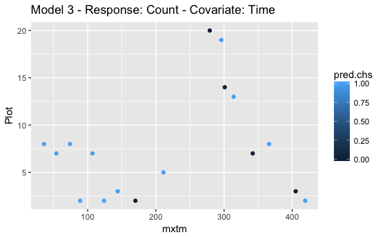

```r
mut_eye_n3x <- cbind(mut_eye_x, predict.statemut_n3x)
ggplot(mut_eye_n3x,aes(mxtm,Plot)) + geom_point(aes(color = pred.chs)) + ggtitle("Model 3 - Response: Count - Covariate: Time")
```

## Model 4

### Response: Count - Covariates: Time, Plot Number, Recent Repeat

```r
set.seed(1)
mod_n4x <- depmix(count ~ 1, transition = ~ mxtm + rrep + plot1 + plot2 + plot3 + plot4 + plot5 + plot6 + plot7 + plot8 + plot9 + plot10 + plot11 + plot12 + plot13 + plot14 + plot15 + plot16 + plot17 + plot18 + plot19 + plot20, data = mut_eye_x, nstates = 2, family=gaussian())
fm_n4x <- fit(mod_n4x)
```

```
iteration 0 logLik: -62.62532
iteration 5 logLik: -56.97299
iteration 10 logLik: -56.92028
iteration 15 logLik: -56.90527
iteration 20 logLik: -56.89827
iteration 25 logLik: -56.89599
iteration 30 logLik: -56.89543
converged at iteration 35 with logLik: -56.89532
```

```r
summary(fm_n4x)
```

```
Initial state probabilties model
pr1 pr2
  0   1

Transition model for state (component) 1
Model of type multinomial (mlogit), formula: ~mxtm + rrep + plot1 + plot2 + plot3 + plot4 + plot5 + plot6 +
    plot7 + plot8 + plot9 + plot10 + plot11 + plot12 + plot13 +
    plot14 + plot15 + plot16 + plot17 + plot18 + plot19 + plot20
Coefficients:
            St1           St2
(Intercept)   0 -8.022281e+01
mxtm          0  3.438153e-01
rrep          0  1.539052e+01
plot1         0  0.000000e+00
plot2         0  1.432924e+01
plot3         0  2.344771e+01
plot4         0  0.000000e+00
plot5         0  1.143361e+01
plot6         0  0.000000e+00
plot7         0 -4.129492e+01
plot8         0 -2.674443e+00
plot9         0  0.000000e+00
plot10        0  0.000000e+00
plot11        0  0.000000e+00
plot12        0  0.000000e+00
plot13        0 -1.850197e+01
plot14        0 -3.461916e+01
plot15        0  0.000000e+00
plot16        0  0.000000e+00
plot17        0  0.000000e+00
plot18        0  0.000000e+00
plot19        0 -3.234245e+01
plot20        0 -4.264031e-04
Probalities at zero values of the covariates.
1 1.444364e-35

Transition model for state (component) 2
Model of type multinomial (mlogit), formula: ~mxtm + rrep + plot1 + plot2 + plot3 + plot4 + plot5 + plot6 +
    plot7 + plot8 + plot9 + plot10 + plot11 + plot12 + plot13 +
    plot14 + plot15 + plot16 + plot17 + plot18 + plot19 + plot20
```

[output cut: 19 more lines]

```
plot15        0   0.00000000
plot16        0   0.00000000
plot17        0   0.00000000
plot18        0   0.00000000
plot19        0  -2.74559579
plot20        0  -9.06185116
Probalities at zero values of the covariates.
0.999999 1.047932e-06


Response parameters
Resp 1 : gaussian
    Re1.(Intercept) Re1.sd
St1          17.250  5.182
St2          42.398 13.545
```

```r
#Pull out parameters
pars_n4x <- getpars(fm_n4x)
#Pull out time (mxtm) values
time_vals_n4x <- dplyr::select(mut_eye_n4x,mxtm)
#Creating temporary transition matrix
#Refresh function - input a for time (mxtm), input b for plot number, c for rrep
tr.refresh_n4x <- function(a,b,c) {
  p11 <- 1/(1+exp(pars_n4x[[4]]+pars_n4x[[8+2*b]]+pars_n4x[[6]]*a+pars_n4x[[8]]*c))
  p21 <- 1/(1+exp(pars_n4x[[50]]+pars_n4x[[54+2*b]]+pars_n4x[[52]]*a+pars_n4x[[54]]*c))
  p12 <- 1 - p11
  p22 <- 1 - p21

  tr.temp_n4x <- c(p11,p21,p12,p22)
  tr.temp_n4x <- matrix(tr.temp_n4x, ncol=2)
}
#Predicted states shell
pr.state_n4x <- matrix(0,nrow(mut_eye_x),2)
#State 1
init.state_n4x <- matrix(c(pars_n4x[[1]],pars_n4x[[2]]),ncol=2) #initial state
a <- mut_eye_x$mxtm[1]
b <- mut_eye_x$Plot[1]
c <- mut_eye_x$rrep[1]
trans_n4x <- tr.refresh_n4x(a,b,c)
pr.state_n4x[1,] <- init.state_n4x %*% trans_n4x

#States 2 onwards (holding probabilities)
for(i in 2:nrow(mut_eye_x)) {
a <- mut_eye_x$mxtm[i]
b <- mut_eye_x$Plot[i]
c <- mut_eye_x$rrep[i]
trans_n4x <- tr.refresh_n4x(a,b,c)
pr.state_n4x[i,] <- pr.state_n4x[i-1,] %*% trans_n4x
}
#Predicted states
predict.state_n4x <- data.frame(prob.s1=pr.state_n4x[,1])
#Making conclusions on state
predict.statemut_n4x <- predict.state_n4x %>% rowwise %>%
  mutate(pred.chs = ifelse(prob.s1 <= 0.5, 0, 1))
mut_eye_n4x <- cbind(mut_eye_x, predict.statemut_n4x)
```

```r
mut_eye_n4x <- mut_eye_n4x %>% rowwise %>%
  mutate(pred.chs = ifelse(pars_n4x[97] >= pars_n5x[95], 1-pred.chs, pred.chs))
```

Now plot

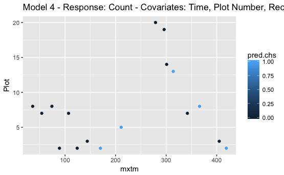

```r
ggplot(mut_eye_n4x,aes(mxtm,Plot)) + geom_point(aes(color = pred.chs)) + ggtitle("Model 4 - Response: Count - Covariates: Time, Plot Number, Recent Repeat")
```

## Model 5

### Response: Count - Covariates: Time, Plot Number, Recent Repeat, Neighbour

```r
set.seed(1)
mod_n5x <- depmix(count ~ 1, transition = ~ mxtm + rrep + nb + plot1 + plot2 + plot3 + plot4 + plot5 + plot6 + plot7 + plot8 + plot9 + plot10 + plot11 + plot12 + plot13 + plot14 + plot15 + plot16 + plot17 + plot18 + plot19 + plot20, data = mut_eye_x, nstates = 2, family=gaussian())
fm_n5x <- fit(mod_n5x)
```

```
iteration 0 logLik: -62.25731
iteration 5 logLik: -56.98555
iteration 10 logLik: -56.92225
iteration 15 logLik: -56.90611
iteration 20 logLik: -56.89813
iteration 25 logLik: -56.89554
iteration 30 logLik: -56.89482
iteration 35 logLik: -56.89468
converged at iteration 39 with logLik: -56.8946
```

```r
summary(fm_n5x)
```

```
Initial state probabilties model
pr1 pr2
  0   1

Transition model for state (component) 1
Model of type multinomial (mlogit), formula: ~mxtm + rrep + nb + plot1 + plot2 + plot3 + plot4 + plot5 + plot6 +
    plot7 + plot8 + plot9 + plot10 + plot11 + plot12 + plot13 +
    plot14 + plot15 + plot16 + plot17 + plot18 + plot19 + plot20
Coefficients:
            St1           St2
(Intercept)   0 -9.556972e+01
mxtm          0  4.241028e-01
rrep          0  1.850571e+01
nb            0 -9.504911e+00
plot1         0  0.000000e+00
plot2         0  2.395010e+01
plot3         0  3.638695e+01
plot4         0  0.000000e+00
plot5         0  1.230557e+01
plot6         0  0.000000e+00
plot7         0 -5.238110e+01
plot8         0 -1.808208e-01
plot9         0  0.000000e+00
plot10        0  0.000000e+00
plot11        0  0.000000e+00
plot12        0  0.000000e+00
plot13        0 -1.883849e+01
plot14        0 -6.592073e+01
plot15        0  0.000000e+00
plot16        0  0.000000e+00
plot17        0  0.000000e+00
plot18        0  0.000000e+00
plot19        0 -3.089101e+01
plot20        0 -1.953193e-04
Probalities at zero values of the covariates.
1 3.123183e-42

Transition model for state (component) 2
Model of type multinomial (mlogit), formula: ~mxtm + rrep + nb + plot1 + plot2 + plot3 + plot4 + plot5 + plot6 +
    plot7 + plot8 + plot9 + plot10 + plot11 + plot12 + plot13 +
```

[output cut: 21 more lines]

```
plot15        0   0.00000000
plot16        0   0.00000000
plot17        0   0.00000000
plot18        0   0.00000000
plot19        0  -5.42855504
plot20        0  -4.95410302
Probalities at zero values of the covariates.
0.9999878 1.221509e-05


Response parameters
Resp 1 : gaussian
    Re1.(Intercept) Re1.sd
St1          17.250  5.182
St2          42.399 13.544
```

```r
#Pull out parameters
pars_n5x <- getpars(fm_n5x)
#Pull out time (mxtm) values
time_vals_n5x <- dplyr::select(mut_eye_n5x,mxtm)
#Creating temporary transition matrix
#Refresh function - input a for time (mxtm), input b for plot number, c for rrep
tr.refresh_n5x <- function(a,b,c,d) {
  p11 <- 1/(1+exp(pars_n5x[[4]]+pars_n5x[[6]]*a+pars_n5x[[10+2*b]]+pars_n5x[[8]]*c+pars_n5x[10]*d))

  p21 <- 1/(1+exp(pars_n5x[[52]]+pars_n5x[[54]]*a+pars_n4x[[58+2*b]]+pars_n5x[[56]]*c+pars_n5x[[58]]*d)) #fix

  p12 <- 1 - p11
  p22 <- 1 - p21

  tr.temp_n5x <- c(p11,p21,p12,p22)
  tr.temp_n5x <- matrix(tr.temp_n5x, ncol=2)
}
#Predicted states shell
pr.state_n5x <- matrix(0,nrow(mut_eye_x),2)
#State 1
init.state_n5x <- matrix(c(pars_n5x[[1]],pars_n5x[[2]]),ncol=2) #initial state
a <- mut_eye_x$mxtm[1]
b <- mut_eye_x$Plot[1]
c <- mut_eye_x$rrep[1]
d <- mut_eye_x$nb[1]
trans_n5x <- tr.refresh_n5x(a,b,c,d)
pr.state_n5x[1,] <- init.state_n5x %*% trans_n5x

#States 2 onwards (holding probabilities)
for(i in 2:nrow(mut_eye_x)) {
a <- mut_eye_x$mxtm[i]
b <- mut_eye_x$Plot[i]
c <- mut_eye_x$rrep[i]
d <- mut_eye_x$nb[i]
trans_n5x <- tr.refresh_n5x(a,b,c,d)
pr.state_n5x[i,] <- pr.state_n5x[i-1,] %*% trans_n5x
}
#Predicted states
predict.state_n5x <- data.frame(prob.s1=pr.state_n5x[,1])
#Making conclusions on state
predict.statemut_n5x <- predict.state_n5x %>% rowwise %>%
  mutate(pred.chs = ifelse(prob.s1 <= 0.5, 0, 1))
mut_eye_n5x <- cbind(mut_eye_x, predict.statemut_n5x)
```

```r
mut_eye_n5x <- mut_eye_n5x %>% rowwise %>%
  mutate(pred.chs = ifelse(pars_n5x[101] >= pars_n5x[99], 1-pred.chs, pred.chs))
```

Now plot

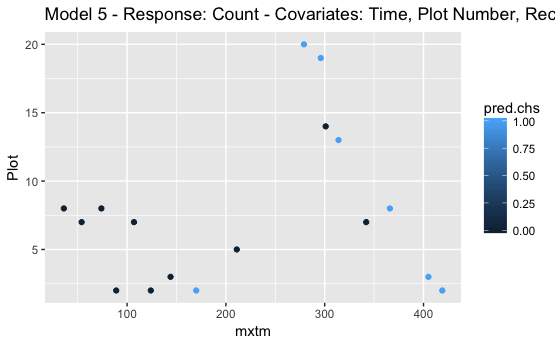

```r
ggplot(mut_eye_n5x,aes(mxtm,Plot)) + geom_point(aes(color = pred.chs)) + ggtitle("Model 5 - Response: Count - Covariates: Time, Plot Number, Recent Repeat, Neighbour")
```

## Model 6

```r
set.seed(1)
mod_n6x <- depmix(list(count ~ 1, rrep ~ 1, nb ~ 1), transition = ~ mxtm + rrep + nb + plot1 + plot2 + plot3 + plot4 + plot5 + plot6 + plot7 + plot8 + plot9 + plot10 + plot11 + plot12 + plot13 + plot14 + plot15 + plot16 + plot17 + plot18 + plot19 + plot20, data = mut_eye_x, nstates = 2, family=list(gaussian(),multinomial("identity"),multinomial("identity")))
fm_n6x <- fit(mod_n6x)
```

```
iteration 0 logLik: -80.65222
iteration 5 logLik: -69.31672
converged at iteration 8 with logLik: -69.16671
```

```r
summary(fm_n6x)
```

```
Initial state probabilties model
pr1 pr2
  0   1

Transition model for state (component) 1
Model of type multinomial (mlogit), formula: ~mxtm + rrep + nb + plot1 + plot2 + plot3 + plot4 + plot5 + plot6 +
    plot7 + plot8 + plot9 + plot10 + plot11 + plot12 + plot13 +
    plot14 + plot15 + plot16 + plot17 + plot18 + plot19 + plot20
Coefficients:
            St1           St2
(Intercept)   0 -5.672742e+01
mxtm          0  3.233884e-01
rrep          0  1.024677e+01
nb            0 -1.043450e+01
plot1         0  0.000000e+00
plot2         0  9.376884e+00
plot3         0 -2.989208e+01
plot4         0  0.000000e+00
plot5         0  1.256629e+01
plot6         0  0.000000e+00
plot7         0 -2.055214e+00
plot8         0  4.359448e+01
plot9         0  0.000000e+00
plot10        0  0.000000e+00
plot11        0  0.000000e+00
plot12        0  0.000000e+00
plot13        0 -1.169415e+01
plot14        0 -3.947813e+01
plot15        0  0.000000e+00
plot16        0  0.000000e+00
plot17        0  0.000000e+00
plot18        0  0.000000e+00
plot19        0 -3.914532e+01
plot20        0 -1.753785e-04
Probalities at zero values of the covariates.
1 2.309916e-25

Transition model for state (component) 2
Model of type multinomial (mlogit), formula: ~mxtm + rrep + nb + plot1 + plot2 + plot3 + plot4 + plot5 + plot6 +
    plot7 + plot8 + plot9 + plot10 + plot11 + plot12 + plot13 +
```

[output cut: 23 more lines]

```
plot17        0   0.00000000
plot18        0   0.00000000
plot19        0  -6.57581941
plot20        0  -3.31400940
Probalities at zero values of the covariates.
0.9999972 2.842893e-06


Response parameters
Resp 1 : gaussian
Resp 2 : multinomial
Resp 3 : multinomial
    Re1.(Intercept) Re1.sd Re2.0 Re2.1 Re3.0 Re3.1
St1          17.455  5.366 0.636 0.364 0.000 1.000
St2          37.833 16.036 1.000 0.000 0.833 0.167
```

```r
#Pull out parameters
pars_n6x <- getpars(fm_n6x)
#Creating temporary transition matrix
#Refresh function - input a for time (mxtm), input b for plot number, c for rrep
tr.refresh_n6x <- function(a,b,c,d) {
  p11 <- 1/(1+exp(pars_n6x[[4]]+pars_n6x[[6]]*a+pars_n6x[[10+2*b]]+pars_n6x[[8]]*c+pars_n6x[10]*d))

  p21 <- 1/(1+exp(pars_n6x[[52]]+pars_n6x[[54]]*a+pars_n4x[[58+2*b]]+pars_n6x[[56]]*c+pars_n6x[[58]]*d)) #fix

  p12 <- 1 - p11
  p22 <- 1 - p21

  tr.temp_n6x <- c(p11,p21,p12,p22)
  tr.temp_n6x <- matrix(tr.temp_n6x, ncol=2)
}
#Predicted states shell
pr.state_n6x <- matrix(0,nrow(mut_eye_x),2)
#State 1
init.state_n6x <- matrix(c(pars_n6x[[1]],pars_n6x[[2]]),ncol=2) #initial state
a <- mut_eye_x$mxtm[1]
b <- mut_eye_x$Plot[1]
c <- mut_eye_x$rrep[1]
d <- mut_eye_x$nb[1]
trans_n6x <- tr.refresh_n6x(a,b,c,d)
pr.state_n6x[1,] <- init.state_n6x %*% trans_n6x
#States 2 onwards (holding probabilities)
for(i in 2:nrow(mut_eye_x)) {
  a <- mut_eye_x$mxtm[i]
  b <- mut_eye_x$Plot[i]
  c <- mut_eye_x$rrep[i]
  d <- mut_eye_x$nb[i]
  trans_n6x <- tr.refresh_n6x(a,b,c,d)
  pr.state_n6x[i,] <- pr.state_n6x[i-1,] %*% trans_n6x
}
#Predicted states
predict.state_n6x <- data.frame(prob.s1=pr.state_n6x[,1])
#Making conclusions on state
predict.statemut_n6x <- predict.state_n6x %>% rowwise %>%
  mutate(pred.chs = ifelse(prob.s1 <= 0.5, 0, 1))
mut_eye_n6x <- cbind(mut_eye_x, predict.statemut_n6x)
```

```r
mut_eye_n6x <- mut_eye_n6x %>% rowwise %>%
  mutate(pred.chs = ifelse(pars_n6x[105] >= pars_n6x[99], 1-pred.chs, pred.chs))
```

Now plot

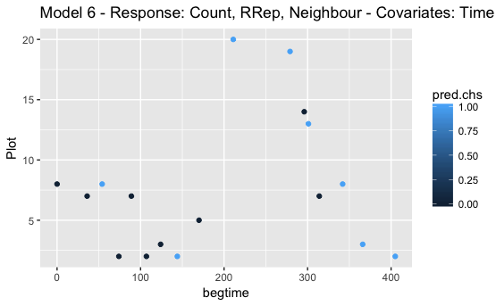

```r
ggplot(mut_eye_n6x,aes(begtime,Plot)) + geom_point(aes(color = pred.chs)) + ggtitle("Model 6 - Response: Count, RRep, Neighbour - Covariates: Time, Plot Number, Recent Repeat, Neighbour")
```

# Now Comparing Plots

Models for consideration: Model 4 - Response: Count - Covariates: Time, Plot Number, Recent Repeat Model 5 - Response: Count - Covariates: Time, Plot Number, Recent Repeat, Neighbour

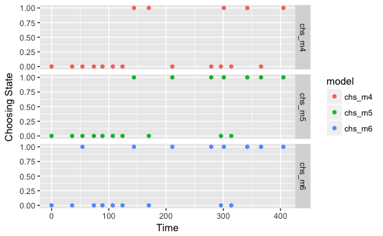

```r
models_df <- cbind(mut_eye_x, chs_m4 = mut_eye_n4x$pred.chs) %>%
 cbind(chs_m5 = mut_eye_n5x$pred.chs) %>%
  cbind(chs_m6 = mut_eye_n6x$pred.chs)
models_long <- models_df %>%
  gather(key = model, value = choosing, chs_m4, chs_m5, chs_m6)
ggplot(models_long, aes(x=begtime,y=choosing)) + geom_point(aes(color = model)) + facet_grid(model~., scale="free_y") + xlab("Time") + ylab("Choosing State")
```

# Percentage of time in choosing state

## Working with model 6

```r
#mutate
#Time In Choosing
#tic <-
```

```r
#mut_eye_x <- mut_eye_x[, !duplicated(colnames(mut_eye_x))] #remove duplicates
#mut_eye_x<- mut_eye_x %>% dplyr::select(-pred.chs,-prob.s1) #remove specific
```

### Collecting information using Model 6 for cross person/image comparisons

I want to: - have a % of time in choosing state for each person/image combo create an interaction of choosing*count for each plot, then do the sum of that column dividied by sum of count - create box plots, side-by-side dotplots - df should be 24x9 - same idea, but possibly % of plots in choosing state (for each combo)